# Data 605 Homework 14 - Taylor Series

Jean Jimenez

2023-12-02

```r
library(ggplot2)
library(Deriv)
```

# Assignment

This week, we’ll work out some Taylor Series expansions of popular functions:

1. $f(x)=\frac{1}{1-x}$
2. $f(x)=e^x$
3. $f(x)=\ln(1+x)$
4. $f(x)=x^\frac{1}{2}$

For each function, only consider its valid ranges as indicated in the notes when you are computing the Taylor Series expansion. Please submit your assignment as an R- Markdown document.

**Taylor Series Expansion Formula**:

$$f(x) = f(a) + f'(a)(x - a) + \frac{f''(a)}{2!}(x - a)^2 +
\frac{f'''(a)}{3!}(x - a)^3 + \cdots$$

For this Homework, I will make a function that will evaluate and calculate the taylor series of each equation:

## #1

$f(x)=\frac{1}{1-x}$

Visualization:

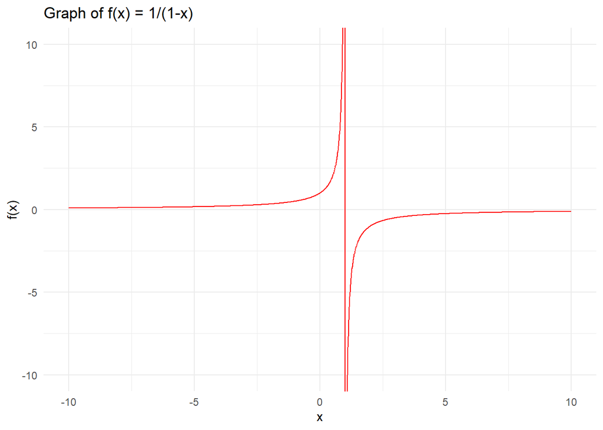

As you can see from the graph, the function $f(x)=\frac{1}{1-x}$ has a vertical asymptote at x=1. When x=1, f(x) is undefined.

$\lim_{{x \to 1 ^-}} f(x)=\infty$

$\lim_{{x \to 1 ^+}} f(x)=-\infty$

Lets do Taylor expansion of f(x) at x=0. I will set a=0. I will be calculating up to the 5th derivative.

```r
# Define the original function and its derivatives
f1 = expression(1 / (1 - x))
d1 = D(f1, "x")
d2 = D(d1, "x")
d3 = D(d2, "x")
d4 = D(d3, "x")
d5 = D(d4, "x")

# Evaluate each derivative at x = 0
f1_0 = eval(f1, list(x = 0))
d1_0 = eval(d1, list(x = 0))
d2_0 = eval(d2, list(x = 0))
d3_0 = eval(d3, list(x = 0))
d4_0 = eval(d4, list(x = 0))
d5_0 = eval(d5, list(x = 0))

#Taylor expansion function
taylor_expansion1 = function(x) {
  f1_0 + d1_0 * x + d2_0 * x^2 / factorial(2) + d3_0 * x^3 / factorial(3) +
    d4_0 * x^4 / factorial(4) + d5_0 * x^5 / factorial(5)
}

# original function
f_original1 = function(x) {
  1 / (1 - x)
}

eval1=0

eval1_orig=eval(f_original1(eval1))

eval1_taylor=eval(taylor_expansion1(eval1))

cat("When centered at X=", eval1, "\n the original function outputs:",eval1_orig,". \n", "the taylor expansion outputs:", eval1_taylor,".\n" )
```

```
## When centered at X= 0
##  the original function outputs: 1 .
##  the taylor expansion outputs: 1 .
```